# (A case study on loan loss analysis of a community bank)

## by (Osama Abdu AlBaset AlShihabi)

## Preliminary Wrangling

> In this study, we conduct a case study on a community bank by the conditions structure for historical loan losses to banks and the loan quality classification matrix used by the bank. Data source from Commercial Bank provided by Google. Basic statistical analysis of loan losses based on the internal loan quality rating system for banks is presented.

```python
# import all packages and set plots to be embedded inline
import numpy as np
import pandas as pd
import matplotlib.pyplot as plt
import seaborn as sb

%matplotlib inline
```

> Load in your dataset and describe its properties through the questions below. Try and motivate your exploration goals through this section.

```python
# load in the dataset into a pandas dataframe, print statistics
loans = pd.read_csv('prosperLoanData.csv')
```

**How many customers does the organization provide for the service to determine the size of the company's portfolio?**

```python
# high-level overview of data shape and composition
loans.shape
```

```
(113937, 81)
```

```python
loans.dtypes
```

```
ListingKey                      object
ListingNumber                    int64
ListingCreationDate             object
CreditGrade                     object
Term                             int64
                                ...
PercentFunded                  float64
Recommendations                  int64
InvestmentFromFriendsCount       int64
InvestmentFromFriendsAmount    float64
Investors                        int64
Length: 81, dtype: object
```

```python
loans.head()
```

|  | ListingKey | ListingNumber | ListingCreationDate | CreditGrade | Term | LoanStatus | ClosedDate | BorrowerAPR | BorrowerRate | LenderYield | ... | LP_ServiceFees | LP_CollectionFees | LP_GrossPrincipalLoss | LP_NetPrincipalLoss | LP_NonPrincipalRecoverypayments | PercentFunded | Recommendations | InvestmentFromFriendsCount | InvestmentFromFriendsAmount | Investors |
| --- | --- | --- | --- | --- | --- | --- | --- | --- | --- | --- | --- | --- | --- | --- | --- | --- | --- | --- | --- | --- | --- |
| 0 | 1021339766868145413AB3B | 193129 | 2007-08-26 19:09:29.263000000 | C | 36 | Completed | 2009-08-14 00:00:00 | 0.16516 | 0.1580 | 0.1380 | ... | -133.18 | 0.0 | 0.0 | 0.0 | 0.0 | 1.0 | 0 | 0 | 0.0 | 258 |
| 1 | 10273602499503308B223C1 | 1209647 | 2014-02-27 08:28:07.900000000 | NaN | 36 | Current | NaN | 0.12016 | 0.0920 | 0.0820 | ... | 0.00 | 0.0 | 0.0 | 0.0 | 0.0 | 1.0 | 0 | 0 | 0.0 | 1 |
| 2 | 0EE9337825851032864889A | 81716 | 2007-01-05 15:00:47.090000000 | HR | 36 | Completed | 2009-12-17 00:00:00 | 0.28269 | 0.2750 | 0.2400 | ... | -24.20 | 0.0 | 0.0 | 0.0 | 0.0 | 1.0 | 0 | 0 | 0.0 | 41 |
| 3 | 0EF5356002482715299901A | 658116 | 2012-10-22 11:02:35.010000000 | NaN | 36 | Current | NaN | 0.12528 | 0.0974 | 0.0874 | ... | -108.01 | 0.0 | 0.0 | 0.0 | 0.0 | 1.0 | 0 | 0 | 0.0 | 158 |
| 4 | 0F023589499656230C5E3E2 | 909464 | 2013-09-14 18:38:39.097000000 | NaN | 36 | Current | NaN | 0.24614 | 0.2085 | 0.1985 | ... | -60.27 | 0.0 | 0.0 | 0.0 | 0.0 | 1.0 | 0 | 0 | 0.0 | 20 |

5 rows × 81 columns

```python
# convert ProsperRating and EmploymentStatus into ordered categorical types
ordinal_var_dict = {'ProsperRating (Alpha)': ['HR','E','D','C','B','A','AA'],
                    'EmploymentStatus': ['Employed','Self-employed','Full-time','Part-time','Retired','Other','Not employed', 'Not available']
                   }

for var in ordinal_var_dict:
    ordered_var = pd.api.types.CategoricalDtype(ordered = True,
                                                categories = ordinal_var_dict[var])
    loans[var] = loans[var].astype(ordered_var)
```

```python
loans_clean = loans.copy()
```

```python
loans_clean.drop(['ListingKey','ListingNumber','ListingCreationDate','EstimatedReturn',
                  'ProsperRating (numeric)','BorrowerState','EmploymentStatusDuration',
                  'CurrentlyInGroup','GroupKey','CreditScoreRangeLower','CreditScoreRangeUpper',
                  'FirstRecordedCreditLine','CurrentCreditLines','OpenCreditLines','TotalCreditLinespast7years',
                  'OpenRevolvingAccounts','OpenRevolvingMonthlyPayment','InquiriesLast6Months','TotalInquiries',
                  'CurrentDelinquencies','AmountDelinquent','BankcardUtilization','LoanKey','ProsperPrincipalOutstanding',
                  'LoanNumber','LoanOriginationDate','LoanOriginationQuarter','MemberKey',
                  'LP_CustomerPayments','LP_CustomerPrincipalPayments','LP_InterestandFees','LP_ServiceFees',
                  'LP_CollectionFees','LP_GrossPrincipalLoss','LP_NonPrincipalRecoverypayments',
                  'Recommendations','InvestmentFromFriendsCount','InvestmentFromFriendsAmount',
                  'ScorexChangeAtTimeOfListing','LoanFirstDefaultedCycleNumber',
                  'ProsperPaymentsLessThanOneMonthLate','ProsperPaymentsOneMonthPlusLate',
                  'CreditGrade','PercentFunded','DateCreditPulled','PublicRecordsLast10Years','PublicRecordsLast12Months',
                  'RevolvingCreditBalance','AvailableBankcardCredit'
                 ],axis=1, inplace = True)
```

```python
loans_clean.head(10)
```

|  | Term | LoanStatus | ClosedDate | BorrowerAPR | BorrowerRate | LenderYield | EstimatedEffectiveYield | EstimatedLoss | ProsperRating (Alpha) | ProsperScore | ... | TotalProsperLoans | TotalProsperPaymentsBilled | OnTimeProsperPayments | ProsperPrincipalBorrowed | LoanCurrentDaysDelinquent | LoanMonthsSinceOrigination | LoanOriginalAmount | MonthlyLoanPayment | LP_NetPrincipalLoss | Investors |
| --- | --- | --- | --- | --- | --- | --- | --- | --- | --- | --- | --- | --- | --- | --- | --- | --- | --- | --- | --- | --- | --- |
| 0 | 36 | Completed | 2009-08-14 00:00:00 | 0.16516 | 0.1580 | 0.1380 | NaN | NaN | NaN | NaN | ... | NaN | NaN | NaN | NaN | 0 | 78 | 9425 | 330.43 | 0.0 | 258 |
| 1 | 36 | Current | NaN | 0.12016 | 0.0920 | 0.0820 | 0.07960 | 0.0249 | A | 7.0 | ... | NaN | NaN | NaN | NaN | 0 | 0 | 10000 | 318.93 | 0.0 | 1 |
| 2 | 36 | Completed | 2009-12-17 00:00:00 | 0.28269 | 0.2750 | 0.2400 | NaN | NaN | NaN | NaN | ... | NaN | NaN | NaN | NaN | 0 | 86 | 3001 | 123.32 | 0.0 | 41 |
| 3 | 36 | Current | NaN | 0.12528 | 0.0974 | 0.0874 | 0.08490 | 0.0249 | A | 9.0 | ... | NaN | NaN | NaN | NaN | 0 | 16 | 10000 | 321.45 | 0.0 | 158 |
| 4 | 36 | Current | NaN | 0.24614 | 0.2085 | 0.1985 | 0.18316 | 0.0925 | D | 4.0 | ... | 1.0 | 11.0 | 11.0 | 11000.0 | 0 | 6 | 15000 | 563.97 | 0.0 | 20 |
| 5 | 60 | Current | NaN | 0.15425 | 0.1314 | 0.1214 | 0.11567 | 0.0449 | B | 10.0 | ... | NaN | NaN | NaN | NaN | 0 | 3 | 15000 | 342.37 | 0.0 | 1 |
| 6 | 36 | Current | NaN | 0.31032 | 0.2712 | 0.2612 | 0.23820 | 0.1275 | E | 2.0 | ... | NaN | NaN | NaN | NaN | 0 | 11 | 3000 | 122.67 | 0.0 | 1 |
| 7 | 36 | Current | NaN | 0.23939 | 0.2019 | 0.1919 | 0.17830 | 0.0799 | C | 4.0 | ... | NaN | NaN | NaN | NaN | 0 | 10 | 10000 | 372.60 | 0.0 | 1 |
| 8 | 36 | Current | NaN | 0.07620 | 0.0629 | 0.0529 | 0.05221 | 0.0099 | AA | 9.0 | ... | NaN | NaN | NaN | NaN | 0 | 3 | 10000 | 305.54 | 0.0 | 1 |
| 9 | 36 | Current | NaN | 0.07620 | 0.0629 | 0.0529 | 0.05221 | 0.0099 | AA | 11.0 | ... | NaN | NaN | NaN | NaN | 0 | 3 | 10000 | 305.54 | 0.0 | 1 |

10 rows × 32 columns

```python
loans_clean.to_csv('AllFiles.csv', encoding = 'utf-8')
```

### What is the structure of your dataset?

> There are total of 113937 loans entries saved in the dataset and 81 attributes. Each loan contain information on the borrowered's background information and details regarding the loans.

### What is/are the main feature(s) of interest in your dataset?

> The following factors were analyzed:

ListingCategory Income ProsperScore EstimatedLoss Investors

Such a study could help MFIs manage credit risk and calculate economic capital. This, in turn, supports the MFI in the event of exceptional economic conditions.

### What features in the dataset do you think will help support your investigation into your feature(s) of interest?

> LenderYield,LoanCurrentDaysDelinquent Term ProsperRating EmploymentStatus TotalProsperPaymentsBilled LoanStatus

Further research can test the accuracy of our findings, or add more insights into credit risk in the microfinance industry.

## Univariate Exploration

> In this section, investigate distributions of individual variables. If you see unusual points or outliers, take a deeper look to clean things up and prepare yourself to look at relationships between variables.

> **The classification of loans identified by the borrower**

To find out the number of loans in the organization, loans are categorized based on the number of customers that the institution provides them with

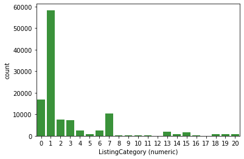

```python
base_color = sb.color_palette()[2]
sb.countplot(data = loans_clean, x = 'ListingCategory (numeric)', color = base_color)
```

```python
loans_clean.dtypes
```

```
Term                                     int64
LoanStatus                              object
ClosedDate                              object
BorrowerAPR                            float64
BorrowerRate                           float64
LenderYield                            float64
EstimatedEffectiveYield                float64
EstimatedLoss                          float64
ProsperRating (Alpha)                 category
ProsperScore                           float64
ListingCategory (numeric)                int64
Occupation                              object
EmploymentStatus                      category
IsBorrowerHomeowner                       bool
DelinquenciesLast7Years                float64
TotalTrades                            float64
TradesNeverDelinquent (percentage)     float64
TradesOpenedLast6Months                float64
DebtToIncomeRatio                      float64
IncomeRange                             object
IncomeVerifiable                          bool
StatedMonthlyIncome                    float64
TotalProsperLoans                      float64
TotalProsperPaymentsBilled             float64
OnTimeProsperPayments                  float64
ProsperPrincipalBorrowed               float64
LoanCurrentDaysDelinquent                int64
LoanMonthsSinceOrigination               int64
LoanOriginalAmount                       int64
MonthlyLoanPayment                     float64
Investors                                int64
dtype: object
```

> **The number of late days**

Reasons for not delaying the loan They may have a return or winnings from the loan and they may have a lot of income

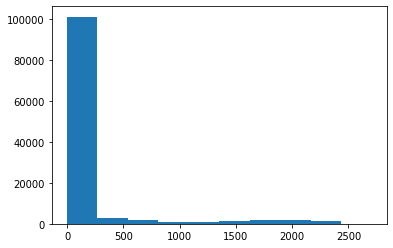

```python
plt.hist(data = loans_clean, x = 'LoanCurrentDaysDelinquent');
```

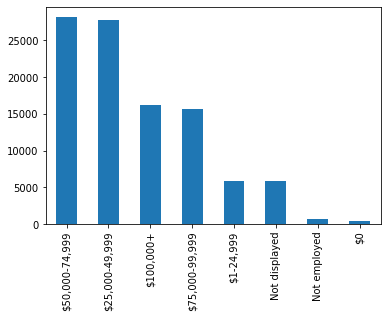

```python
Delinquent_good = (loans_clean.LoanCurrentDaysDelinquent >= 0) & (loans_clean.LoanCurrentDaysDelinquent < 250)
Delinquent_bad = loans_clean.LoanCurrentDaysDelinquent >= 500
loans_clean['IncomeRange'][Delinquent_good].value_counts().plot(kind="bar");
```

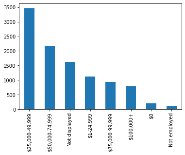

```python
loans_clean['IncomeRange'][Delinquent_bad].value_counts().plot(kind="bar");
```

```python
loans_clean['LenderYield'][Delinquent_good].value_counts()
```

```
0.3077    3110
0.3099    1216
0.3400    1131
0.2599    1109
0.0999     947
          ...
0.3021       1
0.1772       1
0.1936       1
0.1803       1
0.2309       1
Name: LenderYield, Length: 2099, dtype: int64
```

```python
loans_clean['LenderYield'][Delinquent_bad].value_counts()
```

```
0.3400    719
0.3099    301
0.2800    274
0.1900    208
0.1450    193
         ...
0.3239      1
0.2748      1
0.2114      1
0.3048      1
0.2133      1
Name: LenderYield, Length: 1252, dtype: int64
```

The loan repayment is due to the large return on income and the borrower's true desire to pay, as well as the borrower's financial return on the loan is a major reason for repayment.

> Make sure that, after every plot or related series of plots, that you include a Markdown cell with comments about what you observed, and what you plan on investigating next.

> **Look at distributions of term, Prosper rating and employment status**

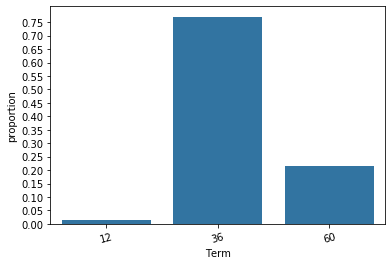

```python
# Term plot
n_points = loans_clean.shape[0]
max_count = loans_clean['Term'].value_counts().max()
max_prop = max_count / n_points

# generate tick mark locations and names
tick_props = np.arange(0, max_prop, 0.05)
tick_names = ['{:0.2f}'.format(v) for v in tick_props]

# create the plot
base_color = sb.color_palette()[0]
sb.countplot(data = loans_clean, x = 'Term', color = base_color)
plt.yticks(tick_props * n_points, tick_names)
plt.ylabel('proportion')

plt.xticks(rotation=15);
```

75% most of the loans are 36 months.

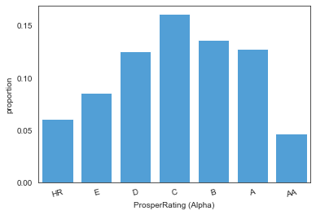

```python
# Term plot
n_points = loans_clean.shape[0]
max_count = loans_clean['ProsperRating (Alpha)'].value_counts().max()
max_prop = max_count / n_points

# generate tick mark locations and names
tick_props = np.arange(0, max_prop, 0.05)
tick_names = ['{:0.2f}'.format(v) for v in tick_props]

# create the plot
base_color = sb.color_palette()[4]
sb.countplot(data = loans_clean, x = 'ProsperRating (Alpha)', color=base_color)
plt.yticks(tick_props * n_points, tick_names)
plt.ylabel('proportion')


plt.xticks(rotation=15);
```

The ratings of most of the borrowers are among D to A.

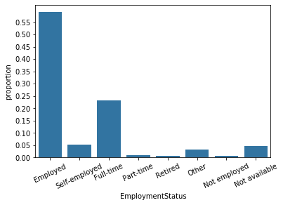

```python
# Term plot
n_points = loans_clean.shape[0]
max_count = loans_clean['EmploymentStatus'].value_counts().max()
max_prop = max_count / n_points

# generate tick mark locations and names
tick_props = np.arange(0, max_prop, 0.05)
tick_names = ['{:0.2f}'.format(v) for v in tick_props]

# create the plot
base_color = sb.color_palette()[0]
sb.countplot(data = loans_clean, x = 'EmploymentStatus', color = base_color)
plt.yticks(tick_props * n_points, tick_names)
plt.ylabel('proportion')

plt.xticks(rotation=25);
```

Most of borrowers are employed and full-time.

### Discuss the distribution(s) of your variable(s) of interest. Were there any unusual points? Did you need to perform any transformations?

> The main variable of interest is ListingCategory, there are no unusual points and no need to perform any transformations. I explored other variables (LoanStatus, ProsperScore, EmploymentStatus,Occupation,Term, Prosper Rating (Alpha)).

## Bivariate Exploration

> In this section, investigate relationships between pairs of variables in your data. Make sure the variables that you cover here have been introduced in some fashion in the previous section (univariate exploration).

> **The relationship between the variable risk (ProsperScore) and the other variable losses (EstimatedLoss)**

Using the plot scatter we estimate the intensity of the points for the probability of estimated losses from the discount operations and the risk value measures taken from the beneficiaries of financing

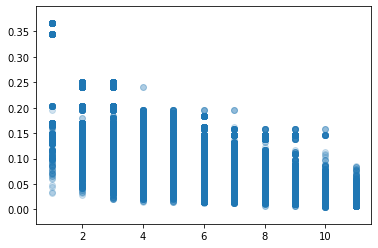

```python
plt.scatter(data = loans_clean, x = 'ProsperScore', y = 'EstimatedLoss', alpha = 1/5);
```

In the scatter diagram, we looked at the relationship between the degree of the fenders and the estimated loss of the opponent's operations. I added some transparency to know the location of the largest part of the data and to know the direction and strength of the relationship between the two variables.

> This data can now be drawn using the Heat map

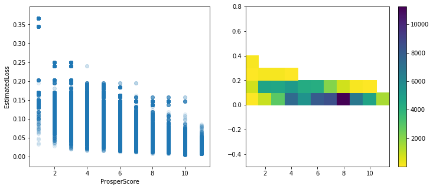

```python
plt.figure(figsize = [12, 5])

# left plot: scatterplot of discrete data with jitter and transparency
plt.subplot(1, 2, 1)
sb.regplot(data = loans_clean, x = 'ProsperScore', y = 'EstimatedLoss', fit_reg = False,
            scatter_kws = {'alpha' : 1/9})

# right plot: heat map with bin edges between values
plt.subplot(1, 2, 2)
bins_x = np.arange(0.5, loans_clean.ProsperScore.max()+1, 1)
bins_y = np.arange(-0.5, loans_clean.EstimatedLoss.max()+0.5, 0.1)
plt.hist2d(data = loans_clean, x = 'ProsperScore', y = 'EstimatedLoss',
           bins = [bins_x, bins_y],cmap = 'viridis_r', cmin = 0.5)
plt.colorbar();
```

Where we can understand the accuracy and understand the order and differences in the number of iterations

In the diagram, we see increased points in the darker retinal cell and fewer points in transparent retinal cells

Where the results show that the percentage of loss is higher for private customers (0-0.2).

> **speed of repayment of the loan type**

A profitable loan to the bank by knowing the speed of repayment of the loan type by knowing the time to repay the loan or the commitment to make the total number of payments

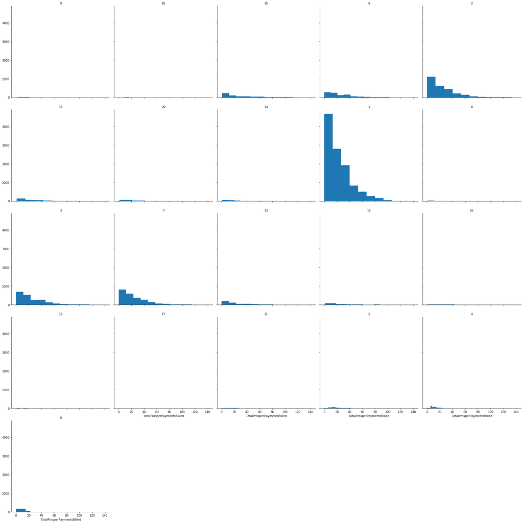

```python
group_means=loans_clean.groupby(['ListingCategory (numeric)']).mean()
group_order = group_means.sort_values(['TotalProsperPaymentsBilled'], ascending = False).index
bin_edges = np.arange(1, loans_clean['TotalProsperPaymentsBilled'].max()+1, 1)
g = sb.FacetGrid(data = loans_clean, col = 'ListingCategory (numeric)',col_wrap = 5, size = 5,col_order = group_order)
g.map(plt.hist, "TotalProsperPaymentsBilled")
g.set_titles('{col_name}')
```

No. 1 turned out to be the most popular loan payment that the bank has given to borrowers

> **The relationship of investors to the success of the project**

The more investors invest in the loan application, the more the project will achieve success and a profitable financial return for the borrower Through the large number of investors requesting the loan, it indicates that the project has an economic feasibility that achieves great profits

```python
loans_clean.Investors.describe()
```

```
count    113937.000000
mean         80.475228
std         103.239020
min           1.000000
25%           2.000000
50%          44.000000
75%         115.000000
max        1189.000000
Name: Investors, dtype: float64
```

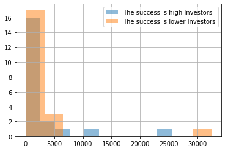

```python
high_investors = loans_clean.Investors > 44
lower_investors = loans_clean.Investors < 44
loans_clean['ListingCategory (numeric)'][high_investors].value_counts().hist(label='The success is high Investors',alpha=0.5)
loans_clean['ListingCategory (numeric)'][lower_investors].value_counts().hist(label='The success is lower Investors',alpha=0.5);
plt.legend();
```

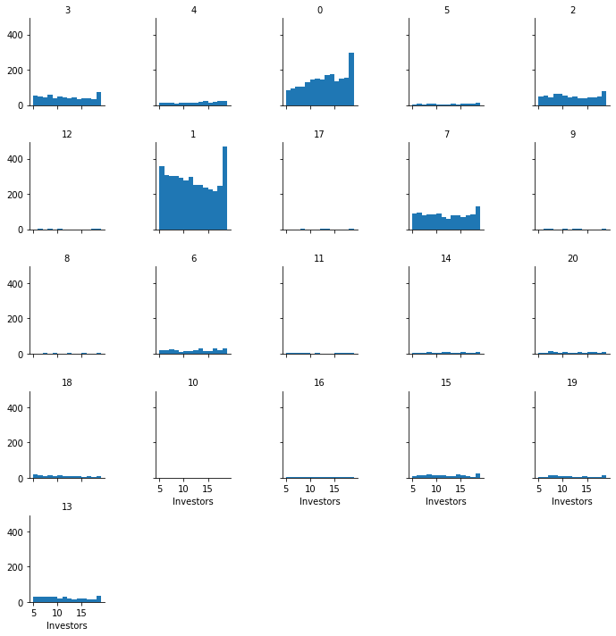

```python
group_means=loans_clean.groupby(['ListingCategory (numeric)']).mean()
group_order = group_means.sort_values(['Investors'], ascending = False).index
g = sb.FacetGrid(data = loans_clean, col = 'ListingCategory (numeric)', col_wrap = 5, size = 2,
                 col_order = group_order)
g.map(plt.hist, 'Investors',bins = np.arange(5, 5+15, 1))
g.set_titles('{col_name}')
```

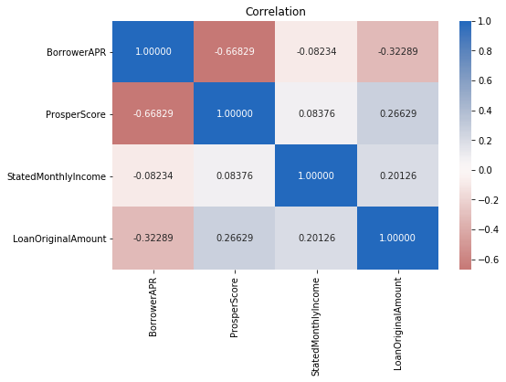

```python
# correlation plot
cols = ['BorrowerAPR', 'ProsperScore','StatedMonthlyIncome', 'LoanOriginalAmount']

plt.figure(figsize = [8, 5])
sb.heatmap(loans_clean[cols].corr(), annot = True, fmt = '.5f',cmap = 'vlag_r', center = 0)
plt.title('Correlation')
plt.show()
```

> **Employment Status compare Loan Status**

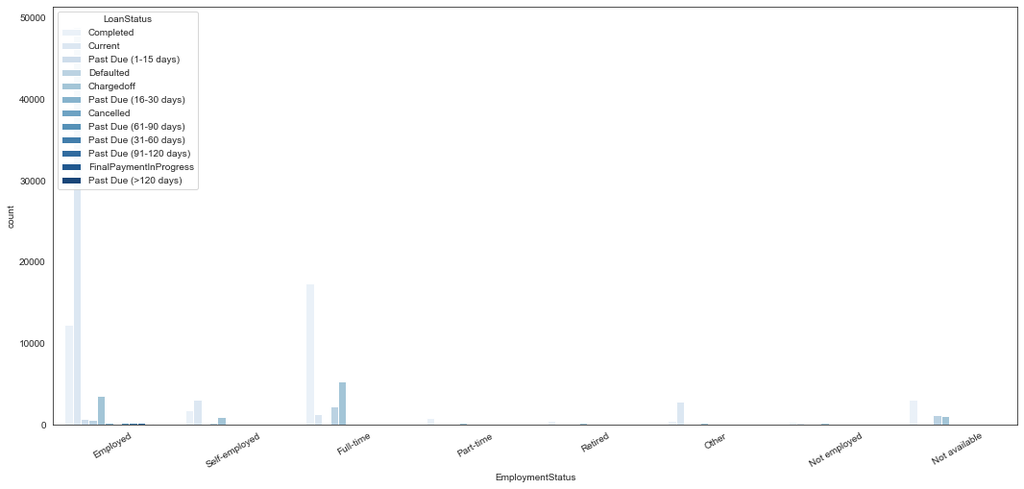

```python
plt.figure(figsize = [18, 8])
sb.countplot(data = loans_clean, x =  'EmploymentStatus', hue = 'LoanStatus', palette = 'Blues')
plt.xticks(rotation=30);
```

most employed borrowers are still have not paid their loans.

> **analyze the capital requirements**

We will analyze the capital requirements based on default, as the company works through financial regulation to determine the capital requirements for each type

```python
print(loans_clean.query('LoanStatus=="Defaulted" &ProsperPrincipalBorrowed>2000').ProsperPrincipalBorrowed[:1000].sum())
print(loans_clean.query('LoanStatus=="Defaulted" &ProsperPrincipalBorrowed<2000').ProsperPrincipalBorrowed[:1000].sum())
```

```
3088422.02
65916.0
```

```python
df=loans_clean.query('LoanStatus=="Defaulted" &ProsperPrincipalBorrowed>2000')[:1000]
df2=loans_clean.query('LoanStatus=="Defaulted" &ProsperPrincipalBorrowed<2000')[:1000]
```

[output not shown]

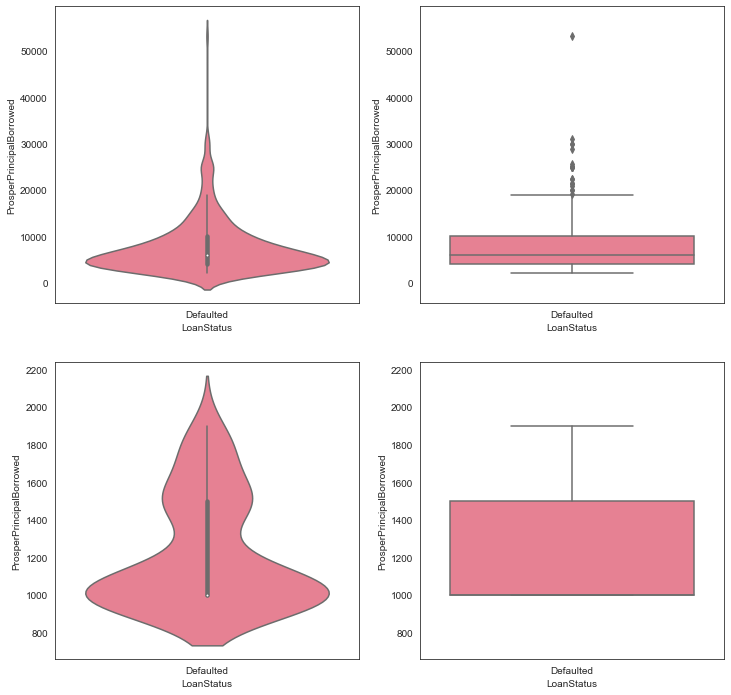

```python
plt.figure(figsize = [12, 12])
base_color = sb.color_palette()[0]

# left plot: violin plot
plt.subplot(2, 2, 1)
ax1 = sb.violinplot(data = df, x = 'LoanStatus', y = 'ProsperPrincipalBorrowed', color = base_color)

# right plot: box plot
plt.subplot(2, 2, 2)
sb.boxplot(data = df, x = 'LoanStatus', y = 'ProsperPrincipalBorrowed', color = base_color)
plt.ylim(ax1.get_ylim()) # set y-axis limits to be same as left plot


# left plot: violin plot
plt.subplot(2, 2, 3)
ax2 = sb.violinplot(data = df2, x = 'LoanStatus', y = 'ProsperPrincipalBorrowed', color = base_color)

# right plot: box plot
plt.subplot(2, 2, 4)
sb.boxplot(data = df2, x = 'LoanStatus', y = 'ProsperPrincipalBorrowed', color = base_color)
plt.ylim(ax2.get_ylim()) # set y-axis limits to be same as left plot
```

In this chart, we calculate descriptive statistics inside each level and visualize them graphically, as we see that the average and the upper and lower edges of the first and third quarters, where 25 percent of the data falls between each group of the first quarter

While the box diagram works well, there are some distributional details that can be lost, so we use a violin plot where the results of Defaulted can include a wide plateau between about 1000 and 5000 points in first plot and between about 800 and 1200 points in second plot.

> **Loan Stutus for each categorized list**

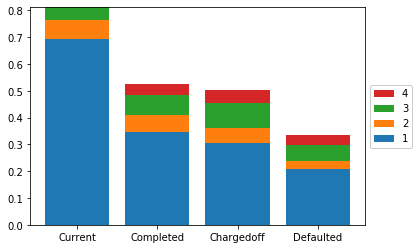

```python
cat1_order = ['Current', 'Completed', 'Chargedoff', 'Defaulted']
cat2_order = [1, 2, 3, 4]

artists = [] # for storing references to plot elements
baselines = np.zeros(len(cat1_order))
cat1_counts = loans_clean['LoanStatus'].value_counts()

# for each second-variable category:
for i in range(len(cat2_order)):
    # isolate the counts of the first category,
    cat2 = cat2_order[i]
    inner_counts = loans_clean[loans_clean['ListingCategory (numeric)'] == cat2]['LoanStatus'].value_counts()
    inner_props = inner_counts / cat1_counts
    # then plot those counts on top of the accumulated baseline
    bars = plt.bar(x = np.arange(len(cat1_order)),
                   height = inner_props[cat1_order],
                   bottom = baselines)
    artists.append(bars)
    baselines += inner_props[cat1_order]

plt.xticks(np.arange(len(cat1_order)), cat1_order)
plt.legend(reversed(artists), reversed(cat2_order), framealpha = 1,
           bbox_to_anchor = (1, 0.5), loc = 6);
```

> **Top Listing Category by interest rate(BorrowerAPR)**

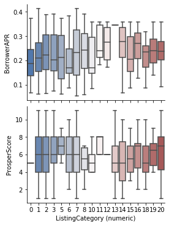

```python
categoric_vars = ['ListingCategory (numeric)']

samples = np.random.choice(loans_clean.shape[0], 2000, replace = False)
loans_samp = loans_clean.loc[samples,:]

def boxgrid(x, y, **kwargs):
    """ Quick hack for creating box plots with seaborn's PairGrid. """
    default_color = sb.color_palette()[0]
    sb.boxplot(x, y, color = default_color,whis=[0, 100], palette="vlag")


plt.figure(figsize = [40, 10])
g = sb.PairGrid(data = loans_samp, y_vars = ['BorrowerAPR', 'ProsperScore'], x_vars = categoric_vars, aspect = 1.5)
g.map(boxgrid)
plt.show();
```

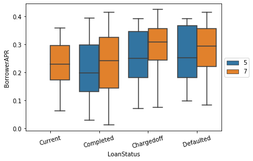

```python
sedan_classes = ['Current', 'Completed', 'Chargedoff', 'Defaulted']
pd_ver = pd.__version__.split(".")
if (int(pd_ver[0]) > 0) or (int(pd_ver[1]) >= 21): # v0.21 or later
    vclasses = pd.api.types.CategoricalDtype(ordered = True, categories = sedan_classes)
    loans_clean['LoanStatus'] = loans_clean['LoanStatus'].astype(vclasses)
else: # compatibility for v.20
    loans_clean['LoanStatus'] = loans_clean['LoanStatus'].astype('category', ordered = True,
                                                         categories = sedan_classes)
loans_clean_sub = loans_clean.loc[loans_clean['ListingCategory (numeric)'].isin([7, 5])]

# plotting
sb.boxplot(data = loans_clean_sub, x = 'LoanStatus', y = 'BorrowerAPR', hue = 'ListingCategory (numeric)')
plt.legend(loc = 6, bbox_to_anchor = (1.0, 0.5)) # legend to right of figure
plt.xticks(rotation = 15)
```

### Talk about some of the relationships you observed in this part of the investigation. How did the feature(s) of interest vary with other features in the dataset?

> No. 1 Listing Category turned out to be the most popular loan payment that the bank has given to borrowers

### Did you observe any interesting relationships between the other features (not the main feature(s) of interest)?

> the percentage of loss is higher for private customers (0-0.2).

## Multivariate Exploration

> Create plots of three or more variables to investigate your data even further. Make sure that your investigations are justified, and follow from your work in the previous sections.

> **we can explain how the borrower's Category or monthly payment relationship between the interest rate and the loan Amoun**

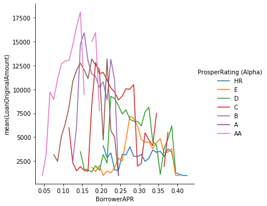

```python
def mean_poly(x, y, bins = 10, **kwargs):
    """ Custom adapted line plot code. """
    # set bin edges if none or int specified
    if type(bins) == int:
        bins = np.linspace(x.min(), x.max(), bins+1)
    bin_centers = (bin_edges[1:] + bin_edges[:-1]) / 2

    # compute counts
    data_bins = pd.cut(x, bins, right = False,
                       include_lowest = True)
    means = y.groupby(data_bins).mean()

    # create plot
    plt.errorbar(x = bin_centers, y = means, **kwargs)

bin_edges = np.arange(0.01, loans_clean['BorrowerAPR'].max()+0.01, 0.01)
g = sb.FacetGrid(data = loans_clean, hue = 'ProsperRating (Alpha)', size = 5)
g.map(mean_poly, "BorrowerAPR", "LoanOriginalAmount", bins = bin_edges)
g.set_ylabels('mean(LoanOriginalAmount)')
g.add_legend()
```

Prosper Rating Effect on Relationship between APR and Loan Amount

The loan amount increases with better rating. The borrower APR decreases with better rating. Interestingly, the relationship between borrower APR and loan amount turns from negative to slightly positive when the Prosper ratings are increased from HR to A or better. This is may because people with A or AA ratings tend to borrow more money, increasting APR could prevent them borrow even more and maximize the profit. But people with lower ratings tend to borrow less money, decreasing APR could encourage them to borrow more.

> **What is the severity of loan losses?**

What is the severity of loan losses during exposure to recovery rates (LP_NetPrincipalLoss) also what is the Defaulted rate (MonthlyLoanPayment) and from these two values we can find the distribution of losses, where from this analysis we would like to determine whether the difference in distributions of loss is due to the difference in the probability of default or to the difference in loss with default or To both. In order to do this, we look at the failure and recovery rates observed in the sample in our hands. The rates of default are analyzed by cohort or type.

```python
loans_clean.LP_NetPrincipalLoss.sum()
```

```
77639007.3877
```

```python
loans_clean.query('LoanStatus=="Defaulted"').MonthlyLoanPayment.sum()
```

```
1171673.93
```

Figures reveal a lower probability of default for customers compared to recovery rates during the period under study, as well as for the average as is the case under conditions of difficulty

```python
print(loans_clean.LP_NetPrincipalLoss.mean())
print(loans_clean.query('LoanStatus=="Defaulted"').MonthlyLoanPayment.mean())
```

```
681.4204989397649
233.494206855321
```

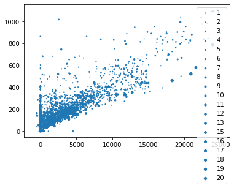

```python
plt.scatter(data = loans_clean.query('LoanStatus=="Defaulted"'), x = 'LP_NetPrincipalLoss', y = 'MonthlyLoanPayment', s = 'ListingCategory (numeric)')

# dummy series for adding legend
sizes = [1,2,3,4,5,6,7,8,9,10,11,12,13,15,16,17,18,19,20]
base_color = sb.color_palette()[0]
legend_obj = []
for s in sizes:
    legend_obj.append(plt.scatter([], [], s = s, color = base_color))
plt.legend(legend_obj, sizes)
```

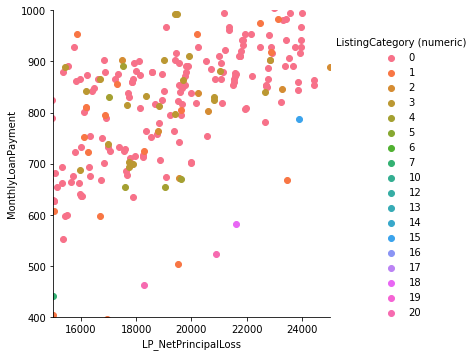

```python
plt.figure(figsize = [8,6])
g = sb.FacetGrid(data = loans_clean.query('LoanStatus=="Defaulted"'), hue = 'ListingCategory (numeric)', size = 5)
g.map(plt.scatter, 'LP_NetPrincipalLoss', 'MonthlyLoanPayment')
plt.xlim(15000,25000)
plt.ylim(400,1000)
g.add_legend();
```

```python
def cuberoot_trans(x, inverse = False):
    """ quick function for computing cube root and cube operations """
    if not inverse:
        return x ** (1/3)
    else:
        return x ** 3
```

[figure not shown]

```python
loans_clean['cr_LP_NetPrincipalLoss'] = loans_clean['LP_NetPrincipalLoss'].apply(cuberoot_trans)
loans_clean['cr_LP_MonthlyLoanPayment'] = loans_clean['MonthlyLoanPayment'].apply(cuberoot_trans)
plt.scatter(data = loans_clean.query('LoanStatus=="Defaulted"'), x = 'cr_LP_NetPrincipalLoss', y = 'cr_LP_MonthlyLoanPayment', s = 'ListingCategory (numeric)')

plt.xlabel('cube root of NetPrincipalLoss')
plt.xscale('log')
plt.yscale('log')

plt.show()
```

### Talk about some of the relationships you observed in this part of the investigation. Were there features that strengthened each other in terms of looking at your feature(s) of interest?

> Figures reveal a lower probability of default for customers compared to recovery rates during the period under study, as well as for the average as is the case under conditions of difficulty

### Were there any interesting or surprising interactions between features?

> The higher the refund, the greater the monthly payment.

> At the end of your report, make sure that you export the notebook as an html file from the `File > Download as... > HTML` menu. Make sure you keep track of where the exported file goes, so you can put it in the same folder as this notebook for project submission. Also, make sure you remove all of the quote-formatted guide notes like this one before you finish your report!